# Chapter 2. VGG - 19 model

## Unit 1. Evolution of CNN models

To just give a brief idea on **Convolutional Neural Network** (**CNN** or **ConvNet**), they are advanced versions of multi-layer neural networks, which can recognise patterns from images. The backbone of these networks are convolutional filters with depth and series of activations. Let's not dig deep in to the CNNs since they may have already been covered in the other chapters previously.

The ImageNet project is a large visual database of labelled images used for visual object recognition research. It runs an annual software contest **ImageNet Large Scale Visual Recognition Challenge**(**ILSVRC**) , where researchers , industries compete to correctly classify and detect objects and scenes from the Imagenet dataset. The evolution of CNN models are hugely attributed to the state of the art papers (models) which achieved highest accuracy in ILSVRC each year.

[figure not shown]

It all started with LeNet (1998). In thee space of 15 years many deep models started making their mark in the ILSVRC. Below is a list of the famous models along with a very brief description

### LeNet in 1998

LeNet is a 7-level convolutional network by LeCun that classifies digits and used by several banks to recognise hand-written numbers on cheques digitized in 32x32 pixel greyscale images. The ability to process higher resolution images requires larger and more convolutional layers, so this technique is constrained by the availability of computing resources.

[figure not shown]

### AlexNet in 2012

In the course of years there was a surge in computational power which enabled the researchers to go ahead of the LeNet. This led to the birth of deep learning and gave rise to ground breaking models.

AlexNet is considered to be the first model which demonstrated the power of Deep-CNNs when it won the ImageNet challenge in 2012. AlexNet is trained on ImageNet and outperformed all the entries that year with a top error rate of 15.3% . It was a major improvement with the next best entry getting only 26.2% top 5 test error rate. Compared to modern architectures, a relatively simple layout was used.

[figure not shown]

### ZFNet in 2013

ZFNet is a modified version of AlexNet which gives a better accuracy.

One major difference in the approaches was that ZF Net used 7x7 sized filters whereas AlexNet used 11x11 filters. The intuition behind this is that by using bigger filters we were losing a lot of pixel information, which we can retain by having smaller filter sizes in the earlier conv layers. The number of filters increase as we go deeper. This network also used ReLUs for their activation and trained using batch stochastic gradient descent.

[figure not shown]

### VGG-Net in 2014

The idea of VGG was submitted in 2013 and it was a runner up in the ImageNet contest in 2014. It is widely used as a simple architecture compared to AlexNet and ZFNet. It was created by the **Visual Geometry Group , Oxford University** , hence the name VGG-Net.

VGG Net used 3x3 filters compared to 11x11 filters in AlexNet and 7x7 in ZFNet. The authors give the intuition behind this that having 2 - 3x3 filters gives an effective receptive field of 5x5, and 3 – 3x3 filters give a receptive field of 7x7 filters, but using this we can reduce the number of parameters in thenetwork

[figure not shown]

### GoogleNet in 2014 (InceptionNet)

In 2014, several great models were developed like VGG but the winner of the ImageNet contest was GoogleNet.

GoogLeNet proposed a module called the inception modules which includes skip connections in the network forming a mini module and this module is repeated throughout the network.

GoogLeNet uses 9 inception module and it eliminates all fully connected layers using average pooling to go from 7x7x1024 to 1x1x1024. This saves a lot of parameters.

[figure not shown]

### ResNet in 2015

This is the modern day highly efficient deep-network . There are 152 layers in the Microsoft ResNet. The authors showed empirically that if you keep on adding layers the error rate should keep on decreasing in contrast to “plain nets” where adding a few layers resulted in higher training and test errors. It took 2 to 3 weeks to train it on an 8 GPU machine. One intuitive reason why residual blocks improve classification is the direct step from one layer to the next and intuitively using all these skip steps form a gradient highway where the gradients computed can directly affect the weights in the first layer making updates have more effect.

[figure not shown]

The present day models are forever improving and mostly built upon the above standard models.

References : For more detailed comparisons please refer the following lecture slides from Stanford : http://cs231n.stanford.edu/slides/2017/cs231n_2017_lecture9.pdf

https://iq.opengenus.org/evolution-of-cnn-architectures/

https://medium.com/@sidereal/cnns-architectures-lenet-alexnet-vgg-googlenet-resnet-and-more-666091488df5

## Unit 2. VGG-19 Architecture

Of the above models , VGG-Net is the most preferred choice in the deeplearning community for extracting features from images.

The main reasons are :

- It has a very straight-forward and uniform arrangement of the layers making it very simple to tap the intermediate outputs necessary for style transfer
- Better models like ResNet, have complex architecture units like residual blocks and skip connections make it complicated to tap the intermediate outputs
- The weight configuration of the VGGNet is publicly available and has been widely used in many other applications and challenges as a baseline feature extractor.

Inspired from Alex-net , this network is known for it's simplicity. As opposed to large kernels like **11x11** and **7x7** used before, VGG-net's main highlight is using smaller (**3×3**) convolutional layers stacked on top of each other in increasing depth. Maxpooling is used to handle the increasing volume size. It starts with a depth of 64 and increases by factor of 2 after each pooling till it reaches 512 . Then, three fully-connected layers, two with 4,096 nodes and one with 1000 nodes are used followed by a softmax classifier. ReLU is used as activation.

The intuition is that more convolution layers with smaller kernels stacked together increases the effective **receptive field** of the network without using high number of parmeters. The receptive field is the effective area of input image on which output depends. Also with more filters the non-linearity increase and so does the depth which helps us learn more coplex features better.

This idea is inspired from the fact that , the number of parameters grows quadratically with kernel size as per the equation ,

\begin{align} \ parameters & = kernel^2 * Cin * Cout \\ \end{align}

where, Cin , Cout are the input and out channels of the layer.

For example :

3 convolutional filters of 3x3 kernels stacked together give us an effective receptive field of a single convolutional filter of 7x7 kernel . Let us now calculate the parameters involved.

For each 3x3 filter , params = 3<sup>2</sup> x Cin x Cout = **9 x Cin x Cout**

For 3 such 3x3 filters , params = 3 x 9 x Cin x Cout = **27 x Cin x Cout**

For 1 , 7x7 filter , params = 7<sup>2</sup> x Cin x Cout = **49 x Cin x Cout**

So using 3 , 3x3 filters we have reduced the parameters by **45%** approximately compared to single 7x7 filters

This makes bigger convolution kernels not cost efficient enough. So replacing them with multiple smaller kernels would give us the same effective receptive field with much lesser parameters.

With a given receptive field(the effective area size of input image on which output depends), multiple stacked smaller size kernel is better than the one with a larger size kernel because multiple non-linear layers increases the depth of the network which enables it to learn more complex features, and that too at a lower cost.

[figure not shown]

The same when represented in spatial domain

[figure not shown]

## Unit 3. VGG-19 in Keras

There are 2 ways to create a model for our applications

1. Build our own model from scratch
2. Transfer Learning

Approach 1 though a good one, needs good amount of time and efforts.It starts right from data creation and then building the architecture, training, monitoring, testing. This will be suitable for applications which need pinpoint accuracy and deal with very unique applications.

Approach 2 ie., transfer learning is quite popular in most of the deeplearning applications wherein we are able to utilise the famous pretrained models for our own applications. The general practice is to strip the layers in the end (any number of layers based on applications) , freeze the remaining part of the network and add our own layers to it. Training this setup on our own data, often gives amazing results in very less time since it utilizes the knowleddge already learnt by the pretrained network. The main reason transfer learning is successful is due to the enormous datasets these state of the art models are trained on. The datasets like Imagenet , COCO cover huge number of real world classes and hence very powerful.

So the advantages are clear, we will use approach 2 since it is faster and known to be reliable. Also style transfer needs us to extract features from intermediate layers and doesn't necessarily needs training a new model

Almost all the deeplearning frameworks support transfer learning by providing pretrained models as APIs. We will now see how simple it is using Keras.

### Loading the VGG-19 model

Keras **Applications** module helps us load famous models alongwith pre-trained weights. These models can be used for prediction, feature extraction, and fine-tuning.For the first time, weights are downloaded automatically when instantiating a model. They are stored at ~/.keras/models/ and will be loaded from the path when we use the model again next time.

Detailed documentation can be found at : https://keras.io/applications/

```python
#from tensorflow.contrib.keras.api.keras.applications import vgg19
from keras.applications import vgg19
def load_VGG19(include_top=False):
    """
     include_top: whether to include the 3 fully-connected layers at the top of the network.
     weights: one of None (random initialization) or 'imagenet' (pre-training on ImageNet)
     input_tensor: optional Keras tensor (i.e. output of layers.Input()) to use as image input for the model

     More options at :
     https://keras.io/applications/#extract-features-from-an-arbitrary-intermediate-layer-with-vgg19
    """
    model = vgg19.VGG19( include_top=include_top,weights='imagenet') # input_tensor=input_tensor
    return model

include_top = True
vgg19_model = load_VGG19(include_top)
```

```python
vgg19_model.summary()
```

```
_________________________________________________________________
Layer (type)                 Output Shape              Param #
=================================================================
input_6 (InputLayer)         (None, 224, 224, 3)       0
_________________________________________________________________
block1_conv1 (Conv2D)        (None, 224, 224, 64)      1792
_________________________________________________________________
block1_conv2 (Conv2D)        (None, 224, 224, 64)      36928
_________________________________________________________________
block1_pool (MaxPooling2D)   (None, 112, 112, 64)      0
_________________________________________________________________
block2_conv1 (Conv2D)        (None, 112, 112, 128)     73856
_________________________________________________________________
block2_conv2 (Conv2D)        (None, 112, 112, 128)     147584
_________________________________________________________________
block2_pool (MaxPooling2D)   (None, 56, 56, 128)       0
_________________________________________________________________
block3_conv1 (Conv2D)        (None, 56, 56, 256)       295168
_________________________________________________________________
block3_conv2 (Conv2D)        (None, 56, 56, 256)       590080
_________________________________________________________________
block3_conv3 (Conv2D)        (None, 56, 56, 256)       590080
_________________________________________________________________
block3_conv4 (Conv2D)        (None, 56, 56, 256)       590080
_________________________________________________________________
block3_pool (MaxPooling2D)   (None, 28, 28, 256)       0
_________________________________________________________________
block4_conv1 (Conv2D)        (None, 28, 28, 512)       1180160
_________________________________________________________________
block4_conv2 (Conv2D)        (None, 28, 28, 512)       2359808
_________________________________________________________________
block4_conv3 (Conv2D)        (None, 28, 28, 512)       2359808
_________________________________________________________________
block4_conv4 (Conv2D)        (None, 28, 28, 512)       2359808
_________________________________________________________________
block4_pool (MaxPooling2D)   (None, 14, 14, 512)       0
_________________________________________________________________
block5_conv1 (Conv2D)        (None, 14, 14, 512)       2359808
_________________________________________________________________
block5_conv2 (Conv2D)        (None, 14, 14, 512)       2359808
_________________________________________________________________
block5_conv3 (Conv2D)        (None, 14, 14, 512)       2359808
_________________________________________________________________
block5_conv4 (Conv2D)        (None, 14, 14, 512)       2359808
_________________________________________________________________
block5_pool (MaxPooling2D)   (None, 7, 7, 512)         0
_________________________________________________________________
flatten (Flatten)            (None, 25088)             0
_________________________________________________________________
fc1 (Dense)                  (None, 4096)              102764544
_________________________________________________________________
fc2 (Dense)                  (None, 4096)              16781312
_________________________________________________________________
predictions (Dense)          (None, 1000)              4097000
=================================================================
Total params: 143,667,240
Trainable params: 143,667,240
Non-trainable params: 0
_________________________________________________________________
```

### Data preprocessing

Since we are using VGG-19 trained on the ImageNet dataset , we need to follow the same preprocessing steps as used for ImageNet dataset.

The basic preprocessing steps employed while training on ImageNet dataset are

- Crop the image to dimensions 224 x 224 which is standard input image size for VGG-net. Random crop is used generally. Centre crop would be better if the object lies in the centre , most of the times
- Horizontal flip
- Normalise the image by 255.0 to get values from 0 to 1
- Mean subtract each channel by ImageNet specfic mean values

  ```
    Red_MEAN = 0.485 (123.68 if not normalised)
    Green_MEAN = 0.456 (116.779 if not normalised )
    Blue_MEAN = 0.406 (103.939 if not normalised )
  ```

- Normalise each channel by ImageNet specfic std deviations (Optional)

  ```
    Red_std = 0.229
    Green_std = 0.224
    Blue_std = 0.225
  ```

The keras vgg19 module has it's own **preprocess_input** method which can help us do this Please refer the function **preprocess(img)** below

Ref : https://github.com/keras-team/keras-applications/blob/master/keras_applications/vgg19.py for the source code of the preprocess_input() function which also highlights the above mean and std values.

```
Input Image
```

```
Preprocessed Image
```

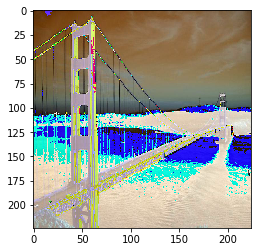

```python
from tensorflow.contrib.keras.api.keras.preprocessing.image import load_img, img_to_array
from keras.applications.imagenet_utils import decode_predictions
import matplotlib.pyplot as plt
%matplotlib inline

def preprocess(img):
   assert(img.ndim == 4 ),"The input images should be of the format : batch_size x 224 x 224 x 3"
   pp_img = vgg19.preprocess_input(img.copy())
   return pp_img

img_path = 'images/content_imgs/bridge.jpg'
img_orig = load_img(img_path, target_size=(224, 224))
img = img_to_array(img_orig)
img = np.expand_dims(img, axis=0) # Batch_size x  imshape format
print("Input Image")
plt.imshow(img[0].astype('uint8'))
plt.show()

pp_img = preprocess(img)
print("Preprocessed Image")
plt.imshow(pp_img[0].astype('uint8'))
plt.show()
```

[output not shown]

### Data deprocessing

We will need a deprocessing function which restores the pixel values in the output image to their original values before normalization. We use the above mentioned mean values for getting the original images back. Please refer the function **deprocess(img)** below

We will be using both teh process and deprocess functions in the upcoming chapters as well.

```
Input Image
```

```
Preprocessed Image
```

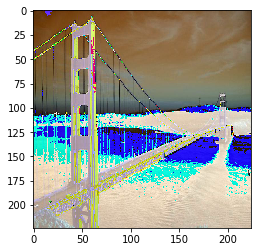

```
Deprocessed Image
```

```python
def deprocess(img):
    assert(img.ndim == 4 ),"The input images should be of the format : batch_size x 224 x 224 x 3"
    dp_img = np.zeros_like(img)
    batch_size = img.shape[0]
    imagenet_mean = [103.939,116.779,123.68]
    for b in range(batch_size):
        for i in range(3): #BGR
            dp_img[b,:,:,i] = img[b,:,:,i] + imagenet_mean[i]
    dp_img = dp_img[:,:,:,::-1]#Make it RGB
    return dp_img

print("Input Image")
plt.imshow(img[0].astype('uint8'))
plt.show()

print("Preprocessed Image")
plt.imshow(pp_img[0].astype('uint8'))
plt.show()

dp_img = deprocess(pp_img) #Observe the input here . It is preprocessed image
print("Deprocessed Image")
plt.imshow(dp_img[0].astype('uint8'))
plt.show()
```

[output not shown]

## Unit 4. Feature extraction

Now that we have loaded the VGG-net and also learnt how to preprocess and deprocess the data , let's look in to

1. Getting predictions from the network using a sample image
2. Extracting feature maps from specific layers

### Getting predictions from the loaded network

```python
img_path = 'images/content_imgs/dog.jpg'
img = load_img(img_path , target_size=(224,224))
img = img_to_array(img)
plt.imshow(img.astype('uint8'))
plt.show()
img = np.expand_dims(img, axis=0) # Batch_size x  imshape format
pp_img = preprocess(img)
preds = vgg19_model.predict(pp_img.astype('float64'))
print('Predicted:', decode_predictions(preds)[0][0])
```

```
Predicted: ('n02110185', 'Siberian_husky', 0.5278538)
```

### Extracting features from the loaded network

We will explore 2 ways to access features from intermediate layers. For that we will need to know the model architecture and naming convention for each layers. This can be obtained using model.summary()

```python
vgg19_model.summary()
```

```
_________________________________________________________________
Layer (type)                 Output Shape              Param #
=================================================================
input_6 (InputLayer)         (None, 224, 224, 3)       0
_________________________________________________________________
block1_conv1 (Conv2D)        (None, 224, 224, 64)      1792
_________________________________________________________________
block1_conv2 (Conv2D)        (None, 224, 224, 64)      36928
_________________________________________________________________
block1_pool (MaxPooling2D)   (None, 112, 112, 64)      0
_________________________________________________________________
block2_conv1 (Conv2D)        (None, 112, 112, 128)     73856
_________________________________________________________________
block2_conv2 (Conv2D)        (None, 112, 112, 128)     147584
_________________________________________________________________
block2_pool (MaxPooling2D)   (None, 56, 56, 128)       0
_________________________________________________________________
block3_conv1 (Conv2D)        (None, 56, 56, 256)       295168
_________________________________________________________________
block3_conv2 (Conv2D)        (None, 56, 56, 256)       590080
_________________________________________________________________
block3_conv3 (Conv2D)        (None, 56, 56, 256)       590080
_________________________________________________________________
block3_conv4 (Conv2D)        (None, 56, 56, 256)       590080
_________________________________________________________________
block3_pool (MaxPooling2D)   (None, 28, 28, 256)       0
_________________________________________________________________
block4_conv1 (Conv2D)        (None, 28, 28, 512)       1180160
_________________________________________________________________
block4_conv2 (Conv2D)        (None, 28, 28, 512)       2359808
_________________________________________________________________
block4_conv3 (Conv2D)        (None, 28, 28, 512)       2359808
_________________________________________________________________
block4_conv4 (Conv2D)        (None, 28, 28, 512)       2359808
_________________________________________________________________
block4_pool (MaxPooling2D)   (None, 14, 14, 512)       0
_________________________________________________________________
block5_conv1 (Conv2D)        (None, 14, 14, 512)       2359808
_________________________________________________________________
block5_conv2 (Conv2D)        (None, 14, 14, 512)       2359808
_________________________________________________________________
block5_conv3 (Conv2D)        (None, 14, 14, 512)       2359808
_________________________________________________________________
block5_conv4 (Conv2D)        (None, 14, 14, 512)       2359808
_________________________________________________________________
block5_pool (MaxPooling2D)   (None, 7, 7, 512)         0
_________________________________________________________________
flatten (Flatten)            (None, 25088)             0
_________________________________________________________________
fc1 (Dense)                  (None, 4096)              102764544
_________________________________________________________________
fc2 (Dense)                  (None, 4096)              16781312
_________________________________________________________________
predictions (Dense)          (None, 1000)              4097000
=================================================================
Total params: 143,667,240
Trainable params: 143,667,240
Non-trainable params: 0
_________________________________________________________________
```

### Using Keras Backend Functionality **'K'**

```python
from keras import backend as K
get_layer_output = K.function([vgg19_model.layers[0].input],
                                  [vgg19_model.layers[3].output])
method1_features = get_layer_output([pp_img])[0]
print(method1_features.shape)
```

```
(1, 112, 112, 64)
```

### Using Keras.models.Model

```python
from keras.models import Model
layer_name = 'block1_pool'
intermediate_layer_model = Model(inputs=vgg19_model.input,
                                 outputs=vgg19_model.get_layer(layer_name).output)
method2_features = intermediate_layer_model.predict(pp_img)
print(method2_features.shape)
```

```
(1, 112, 112, 64)
```

We can see that both the above methods produce the same output since the difference between the feature maps extracted is 0.

```python
print(np.max(method2_features - method1_features))
```

```
0.0
```

### Visualising some feature maps from different stages of network

We extract feature maps at :

block1_pool - Pool 1 (Near Begining)

block2_pool - Pool 2

block3_pool - Pool 3

block4_pool - Pool 4 (Near End)

We can clearly see that the features extracted quite prominent in the start (Pool 1) and slowly become more and more specific as we move towards end of the network (Pool 4)

At Pool 1 , we can easily identify the outline of the Husk , more like an edge image. Hence the initial layers are good at identifying the overall texture and objects in the image.

At Pool 4 , we can only see fragmented features which probably are finer level features extracted across 512 feature maps. The layers towards end are good at identifying the fine and specific details like eyes , ears etc.

### Block1_Pool

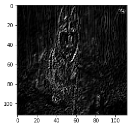

```python
plt.imshow(img[0].astype('uint8'))
plt.show()
plt.gray()
plt.imshow(method1_features[0,:,:,0])
plt.show()
```

### Block2_Pool

```
(1, 56, 56, 128)
```

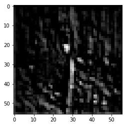

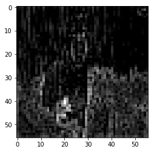

```python
layer_name = 'block2_pool'
intermediate_layer_model = Model(inputs=vgg19_model.input,
                                 outputs=vgg19_model.get_layer(layer_name).output)
method2_features2 = intermediate_layer_model.predict(pp_img)
print(method2_features2.shape)


plt.imshow(img[0].astype('uint8'))
plt.show()
plt.gray()
plt.imshow(method2_features2[0,:,:,0])
plt.show()
plt.imshow(method2_features2[0,:,:,64])
plt.show()
```

### Block3_Pool

```
(1, 28, 28, 256)
```

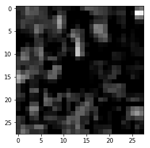

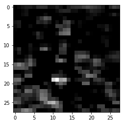

```python
layer_name = 'block3_pool'
intermediate_layer_model = Model(inputs=vgg19_model.input,
                                 outputs=vgg19_model.get_layer(layer_name).output)
method2_features3 = intermediate_layer_model.predict(pp_img)
print(method2_features3.shape)

plt.imshow(img[0].astype('uint8'))
plt.show()
plt.gray()
plt.imshow(method2_features3[0,:,:,0])
plt.show()
plt.imshow(method2_features3[0,:,:,128])
plt.show()
```

### Block4_Pool

```
(1, 14, 14, 512)
```

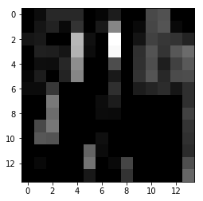

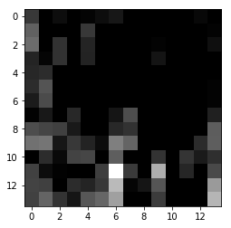

```python
layer_name = 'block4_pool'
intermediate_layer_model = Model(inputs=vgg19_model.input,
                                 outputs=vgg19_model.get_layer(layer_name).output)
method2_features4 = intermediate_layer_model.predict(pp_img)
print(method2_features4.shape)

plt.imshow(img[0].astype('uint8'))
plt.show()
plt.gray()
plt.imshow(method2_features4[0,:,:,0])
plt.show()
plt.imshow(method2_features4[0,:,:,32])
plt.show()
```

Now that we have learnt to load a VGG-19 model in Keras and also to extract features , it's time to experiment on your own . Next chapter we will go deeper in to using all our learnings so far to build a Style Transfer Pipeline